# Programming Assignment 4 - EE6132

#### submitted by - Chitranshu Vashishth [ME17B105]

## Task 1 - SFM

```python
# Importing libraries
import scipy.io as sio
from scipy.optimize import least_squares
import matplotlib.pyplot as plt
import numpy as np
import cv2
```

Loading Camera intrinsics and matching points to the jupyter notebook

```python
K = sio.loadmat('IntrinsicsMCV.mat')['IntrinsicMatrix']
match_points = sio.loadmat('matchedPoints.mat')['matchedPoints']
```

```python
print("Shape of matched points array:", match_points.shape, '\n')
print("Intrinsic camera matrix:\n", K)
```

```
Shape of matched points array: (807, 2, 25)

Intrinsic camera matrix:
 [[720.6605049    0.         420.22416865]
 [  0.         720.05791688 316.64872007]
 [  0.           0.           1.        ]]
```

## Converting image coordinates to normalized coordinates

```python
pij_x = (match_points[:,0,:] - K[0,2]) / K[0,0]
pij_y = (match_points[:,1,:] - K[1,2]) / K[1,1]

matches_normalized = np.dstack((pij_x, pij_y))
num_points = matches_normalized.shape[0]
matches = matches_normalized
```

```python
print(matches_normalized.shape)
```

```
(807, 25, 2)
```

Conversion matrices to handle rotation matrix convversion from theta matrix and vice-versa

```python
def rot_to_theta(R):
    thetas = np.empty(3)
    thetas[0] = R[2, 1]
    thetas[1] = R[0, 2]
    thetas[2] = R[1, 0]
    return thetas
```

```python
def theta_to_rot(thetas):
    R = np.array([[1,          -thetas[2], thetas[1]],
                  [thetas[2],  1,          -thetas[0]],
                  [-thetas[1], thetas[0],  1]])
    return R
```

## Projection function that takes world coordinates and convert them to image coordinates

```python
def projection(three_D_points, thetas, t):
    R = theta_to_rot(thetas)
    three_D_points = np.reshape(three_D_points, (num_points, 3))
    three_D_points = np.transpose(three_D_points)
    translations = np.repeat(t[:, np.newaxis], num_points, axis=1)
    translations = np.squeeze(translations, axis=2)
    transformed_points = R @ three_D_points + translations
    projected_points = np.empty((2, num_points))
    projected_points[0] = np.divide(transformed_points[0], transformed_points[2])
    projected_points[1] = np.divide(transformed_points[1], transformed_points[2])
    projected_points = np.transpose(projected_points)
    return projected_points
```

## Calculation Reprojection Error

```python
def reprojection_error(parameters):
    #Separate parameters from unrolled parameter vector
    translations = parameters[:num_frames*3].reshape((num_frames,3))
    thetas = parameters[num_frames*3:num_frames*6].reshape((num_frames,3))
    inv_depths = parameters[num_frames*6:]
    depths = 1 / inv_depths

    error = 0
    for i in range(num_frames):
        points_x = matches_normalized[:,i,0]
        points_y = matches_normalized[:,i,1]
        points_3d = np.multiply(depths, np.vstack((points_x, points_y, np.ones(points_x.shape))))
        projected_points = projection(points_3d, thetas[i], np.reshape(translations[i],(3,1)))
        error = error + np.sum((projected_points - matches_normalized[:,i,:])**2)
    return error
```

## Bundle Adjustment

```python
def bundle_adjustment(num_frames):
    num_points = matches_normalized.shape[0]
    matches = matches_normalized[:,:num_frames,:]
    translations = np.zeros((num_frames,3))
    thetas = np.zeros((num_frames,3))
    inv_depths = np.ones(matches.shape[0])

    initial_guess = np.hstack((translations.ravel(), thetas.ravel(), inv_depths))
    res = least_squares(fun=reprojection_error, x0=initial_guess, max_nfev=100, verbose=1)

    optima = res['x']
    translations = optima[:3*num_frames].reshape((num_frames,3))
    thetas = optima[3*num_frames:6*num_frames].reshape((num_frames,3))
    inverse_depths = optima[6*num_frames:]
    return translations, thetas, inverse_depths
```

## Plot Point cloud function

```python
def plot_point_cloud(points_3d, num_frames):
    fig = plt.figure(figsize=(10,8))
    ax = fig.add_subplot(111, projection='3d')

    for i in range(points_3d.shape[0]):
        x, y, z = points_3d[i,0], points_3d[i,1], points_3d[i,2]
        ax.scatter(x, y, z)

    ax.set_xlabel('X')
    ax.set_ylabel('Y')
    ax.set_zlabel('Z')
    ax.set_zlim3d(0.8,1.2)
    plt.title("Point Cloud for M = " + str(num_frames) + " frames")
    plt.show()
```

## Visualiation of 3D points

```
The maximum number of function evaluations is exceeded.
Function evaluations 100, initial cost 4.5508e+09, final cost 3.4568e+04, first-order optimality 1.24e+03.
```

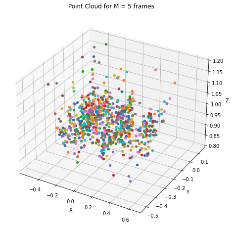

```
The maximum number of function evaluations is exceeded.
Function evaluations 100, initial cost 2.4214e+13, final cost 4.7251e+09, first-order optimality 2.46e+10.
```

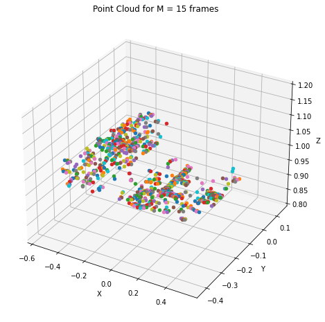

```
The maximum number of function evaluations is exceeded.
Function evaluations 100, initial cost 4.1882e+13, final cost 2.0325e+10, first-order optimality 1.40e+11.
```

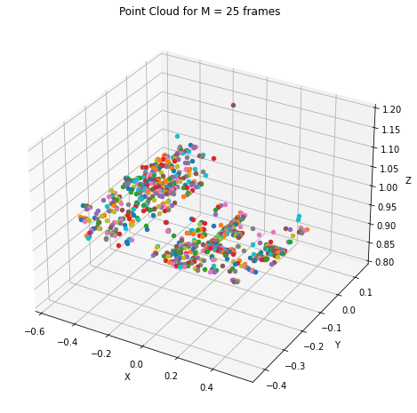

```
CPU times: user 8min 25s, sys: 1.24 s, total: 8min 26s
Wall time: 7min 33s
```

```python
%%time
# All the variables with names appended by _frames denote special kind of data structure here
# This is done to store the data for all the frame sizes (5,15,25) here.
# These tensors are of size (3, :, :)
translations_frames = np.empty((3,25,3))
thetas_frames = np.empty((3,25,3))
points_3d_frames = np.empty((3,num_points,3))
for num_frames in [5, 15, 25]:
    translations, thetas, inverse_depths = bundle_adjustment(num_frames)
    depths = 1 / inverse_depths
    points_3d = np.empty((num_points, 3))
    points_3d[:,0] = np.multiply(depths, matches_normalized[:,0,0])
    points_3d[:,1] = np.multiply(depths, matches_normalized[:,0,1])
    points_3d[:,2] = depths
    translations_frames[int((num_frames-5)/10),:num_frames,:] = translations
    thetas_frames[int((num_frames-5)/10),:num_frames,:] = thetas
    points_3d_frames[int((num_frames-5)/10),:,:] = points_3d
    plot_point_cloud(points_3d, num_frames)
```

The reconstruction with only 5 frame views was bit noisy also. The bundle adjustment algorithm is heavily dependent on the initial condition and hence there is always noise present in these situations.

## Task2 - Dense Depth Reconstruction

```python
normal = np.array([0, 0, 1])
normal = np.expand_dims(normal, axis=1)
max_depth = np.max(depths)
min_depth = np.min(depths)
candidate_depths = np.linspace(min_depth, max_depth, 10)
homography_frames = np.empty((3, 10, num_frames, 3, 3))
for num_frames in [5, 15, 25]:
    frame_index = int((num_frames-5)/10)
    for i in range(10):
        for j in range(num_frames):
            R = theta_to_rot(thetas_frames[frame_index, j])
            t = translations_frames[frame_index, j]
            t = np.expand_dims(t, axis=1)
            homography_frames[frame_index, i, j] = K @ (
                R - ((normal @ np.transpose(t))/candidate_depths[i])) @ np.linalg.inv(K)
```

The calculated homography matrices will be used to cocnduct plane sweep stereo.

For a plane at depth d and with normal vector n, the plane-induced homography mapping the reference frame to the ith frame is given by this homography matrix which is written in form of frame_index to take care of different frames.

## A display image function to display images

```python
def display_img(img, title=""):
    fig, ax = plt.subplots(figsize = (10,7))
    ax.imshow(img)
    ax.set_title(title)
    ax.axis("off");
```

## Constructing plane sweep stereo tensor

Mapping the ith frame to the reference frame through the plane induced homography. The inversion of H is taken care of by c2.warpPerspective. The size of homogrpahy_frame has additional dimension denoting 3 frame sizes (5,15,25)

```python
img_ref = cv2.imread("./sequence/IMG_1096.JPG", 0)
# Indexed by num_frames, candidate depths, total views, image size
plane_sweep_tensor = np.empty((3, 10, 25, img_ref.shape[0], img_ref.shape[1]))
for num_frames in [5, 15, 25]:
    frame_index = int((num_frames-5)/10)
    for depth in range(10):
        for frame in range(num_frames):
            img_init = cv2.imread(f"./sequence/IMG_{1096+frame}.JPG", 0)
            hmg = homography_frames[frame_index, depth, frame]
            plane_sweep_tensor[frame_index, depth, frame] = cv2.warpPerspective(
                img_init, homography_frames[frame_index, depth, frame], (img_init.shape[1], img_init.shape[0]))
```

## Finding the depth map

Finding the variance along the frame axis, and then find the depth index which minimizes it. The corresponding index gives us the actual depth value that can then be displayed.

```python
variance_tensor = np.var(plane_sweep_tensor, axis=2)
depth_loc_tensor = np.argmin(variance_tensor, axis=1)
```

```python
depth_tensor = np.empty_like(depth_loc_tensor, dtype=float)
for num_frames in [5, 15, 25]:
    frame_index = int((num_frames-5)/10)
    for height in range(depth_loc_tensor.shape[1]):
        for width in range(depth_loc_tensor.shape[2]):
            index = depth_loc_tensor[frame_index, height, width]
            depth_tensor[frame_index, height, width] = candidate_depths[index]
```

## Displaying the depth maps

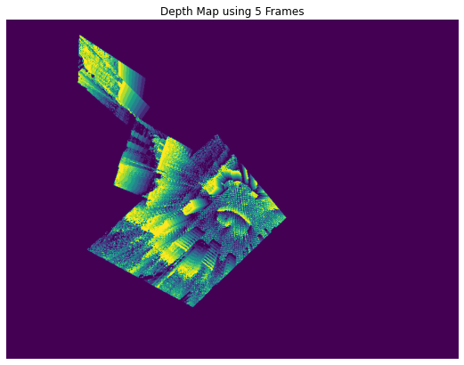

```python
display_img(depth_tensor[0], "Depth Map using 5 Frames")
```

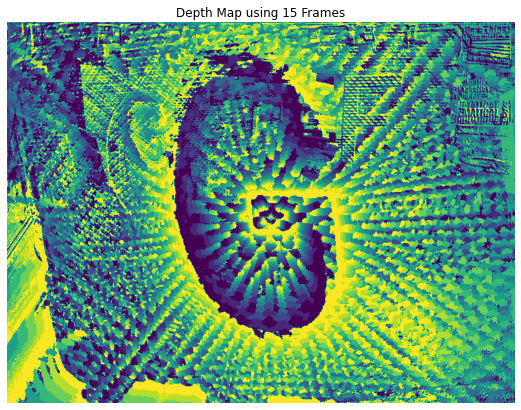

```python
display_img(depth_tensor[1], "Depth Map using 15 Frames")
```

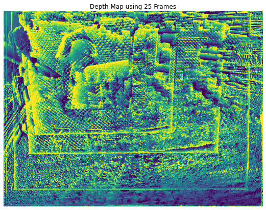

```python
display_img(depth_tensor[2], "Depth Map using 25 Frames")
```

Another reason for not depth reconstructions are not perfect and have some kind of noise in them. This is likely due to noise in the parameters in the bundle adjustment parameters. More spacing between candidate depth values could have helped maybe. There also seem to be some error due to limitation of keeping the size of warped image as it as the input image. There were some problems in doing it in the natural way.